# 08-Correlation Analysis

Author

Published

September 18, 2025

# 1 Intro

This is a [Quarto](https://quarto.org) file. Quarto enables you to weave together content and executable code into a finished document. When you execute code within the notebook, the results appear beneath the code. This allows you to share your analyses and results with others so that they can see the results in line with the code for reproducibility. Make sure to have only one sentence per line. To learn more about Quarto see https://quarto.org. For course instructions on using Quarto, see here: https://isaactpetersen.github.io/QuartoBlogFantasyFootball/posts/quarto-instructions/.

# 2 Preamble

## 2.1 Install Libraries

```r
#install.packages("remotes")
#remotes::install_github("DevPsyLab/petersenlab")
#remotes::install_github("FantasyFootballAnalytics/ffanalytics")

#update.packages(ask = FALSE)
```

## 2.2 Load Libraries

```r
library("petersenlab")
library("XICOR")
library("psych")
library("DescTools")
library("psych")
library("correlation")
library("effectsize")
library("GGally")
library("ggridges")
library("tidyverse")
```

## 2.3 Load Data

Load the data file that is in the following location: `./Data/player_stats_weekly.Rdata` (if running locally) or `../Data/player_stats_weekly.Rdata` (if rendering).

```r
load("../Data/player_stats_weekly.Rdata")
```

# 3 Correlation Coefficient

What is the association (*r*- and *p*-value) between target share (`target_share`) and fantasy points (`fantasyPoints`) among WRs?

```r
cor.test(
  ~ target_share + fantasyPoints,
  data = player_stats_weekly %>% filter(position == "WR")
)
```

```
    Pearson's product-moment correlation

data:  target_share and fantasyPoints
t = 232.29, df = 44593, p-value < 2.2e-16
alternative hypothesis: true correlation is not equal to 0
95 percent confidence interval:
 0.7357150 0.7441146
sample estimates:
      cor
0.7399437
```

# 4 Correlation Matrix

Provide a correlation matrix (of *r*, *n*, and *p*-values) of the following variables among WRs: age, height, target share (`target_share`), and fantasy points (`fantasyPoints`).

```r
petersenlab::cor.table(
  player_stats_weekly %>% filter(position == "WR") %>% select(age, height, target_share, fantasyPoints)
)
```

```
                        age  height target_share fantasyPoints
1. age.r               1.00 -.03***       .09***        .09***
2. sig                   NA     .00          .00           .00
3. n                  55941   55941        44308         55941
4. height.r         -.03***    1.00       .13***        .11***
5. sig                  .00      NA          .00           .00
6. n                  55941   55941        44308         55941
7. target_share.r    .09***  .13***         1.00        .74***
8. sig                  .00     .00           NA           .00
9. n                  44308   44308        44595         44595
10. fantasyPoints.r  .09***  .11***       .74***          1.00
11. sig                 .00     .00          .00            NA
12. n                 55941   55941        44595         56352
```

# 5 Correlogram (Correlation Matrix Plot)

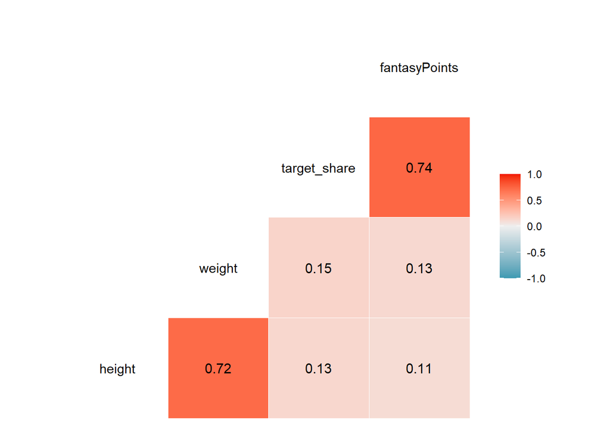

```r
GGally::ggcorr(
  player_stats_weekly %>% filter(position == "WR") %>% select(height, weight, target_share, fantasyPoints),
  label = TRUE,
  label_round = 2)
```

# 6 Scatterplot with Best-Fit Line

Provide a scatterplot with a best-fit line of the association between target share (`target_share`) and fantasy points (`fantasyPoints`) among WRs. Have target share on the x-axis and fantasy points on the y-axis. What is the shape of the association?

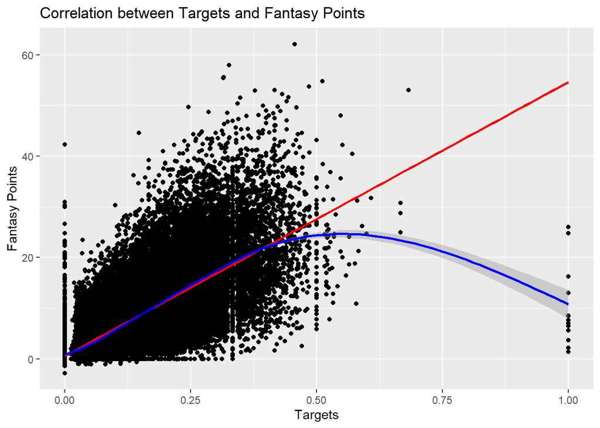

```r
ggplot2::ggplot(
  data = player_stats_weekly %>% filter(position == "WR"),
  aes(
    x = target_share,
    y = fantasyPoints)) +
  geom_point() +
  geom_smooth(
    method = "lm",  # linear best-fit line
    color = "red") +
  geom_smooth(
    method = "gam", # nonlinear best-fit line
    color = "blue"
  ) +
  labs(
    x = "Targets",
    y = "Fantasy Points",
    title = "Correlation between Targets and Fantasy Points"
  )
```